# Live-Presentation by an Example

[figure not shown]

## Manuel Behrendt

In my daily life, I use "Jupyter lab" on my laptop. The data is stored on a powerful server where Jupyter is running which I can connect remotely. In this Jupyter notebook, I present a preliminary version of MERA, fully executed on my laptop (MacBookPro with processor: 2.4 GHz Intel Core i7; memory: 16 GB 1867 MHz LPDDR3). With tic(), toc() I measure the elapsed execution time of some functions.

## Load the MERA Package and Get an Overview of a Simulation Output

The function "get_info" prints a small overview in human readable units and passes many simulation properties into the object "info" (here):

```julia
using Mera
info = get_info(NOutput=400, Path="../simulations/");
```

```
[Mera]: 2018-09-19T17:41:32.321

output [400] summary:
-------------------------------------------------------
simulation time: 594.977 [Myr]
boxlen: 48.0 [kpc]
ncpu: 2048
ndim: 3
level(s): 6 - 14 --> cellsize(s): 750.0 [pc] - 2.92968 [pc]
hydro-variables: 7  -->String["rho", "vx", "vy", "vz", "p", "var6", "var7"]
gravity: true
particles: true
- Npart:    5.091500e+05
- Nstars:   5.066030e+05
- Ndm:      2.547000e+03
- Nsinks:   0.000000e+00
clumps: true
infofile creation-time: 1.5361411150412552e9 ms
infofile modification-time: 1.5361411150412552e9 ms
-------------------------------------------------------
```

## Load the Hydro Data

- read the densities and vertical velocities up to level 13 from 2048 hydro-files of the full box
- takes ~1.5 minutes on my laptop

```julia
gas = get_hydro(info, lmax =13, vars=["rho", "vz"]);
```

[figure not shown]

### Fast loading from compressed "HDF5" files

- I am converting the RAMSES data into compressed single files/output folder
- Can save significant space, depending on the AMR structure
- The data can be loaded within a few seconds (no memory mapping) -> good for time sequence analysis
- PS: Looking forward to use the HERCULE package soon (talk from Monday)

```julia
tic()
gas = read_mera("output_400");
toc();
```

```
elapsed time: 0.370895973 seconds
```

```
WARNING: replacing module mytype
WARNING: ignoring conflicting import of mytype.mytype into JLD
```

```julia
memory_used(gas);
```

```
Memory used :2.4451830433681607 GB
```

## Data is stored into a data base framework

```julia
gas.data
```

```
Table with 32818444 rows, 10 columns:
Columns:
#   colname  type
────────────────────
1   level    Int64
2   cpu      Int64
3   cx       Int64
4   cy       Int64
5   cz       Int64
6   x        Float64
7   y        Float64
8   z        Float64
9   rho      Float64
10  vz       Float64
```

Each row corresponds to a cell:

```julia
select(gas.data, (:x, :y, :z, :rho, :vz))
```

```
Table with 32818444 rows, 5 columns:
x        y        z        rho         vz
─────────────────────────────────────────────────
0.75     0.75     0.75     1.47746e-5  0.116751
0.75     0.75     1.5      1.47746e-5  0.168628
0.75     0.75     2.25     1.47746e-5  0.183555
0.75     0.75     3.0      1.47746e-5  0.186861
0.75     0.75     3.75     1.47746e-5  0.185921
0.75     0.75     4.5      1.47746e-5  0.183455
0.75     0.75     5.25     1.47746e-5  0.179809
0.75     0.75     6.0      1.47746e-5  0.175403
0.75     0.75     6.75     1.47746e-5  0.170531
0.75     0.75     7.5      1.47746e-5  0.16534
0.75     0.75     8.25     1.47746e-5  0.159946
0.75     0.75     9.0      1.47746e-5  0.15441
⋮
38.2266  25.9805  23.7773  0.314544    0.112327
38.2266  25.9805  23.7832  0.301562    0.0802883
38.2266  25.9805  23.7891  0.295276    0.0734515
38.2266  25.9805  23.7949  0.280634    0.0421302
38.2266  25.9805  23.8008  0.276197    0.035852
38.2266  25.9805  23.8066  0.262428    0.00710172
38.2266  25.9805  23.8125  0.259527    0.0014367
38.2266  25.9805  23.8184  0.24997     -0.02134
38.2266  25.9805  23.8242  0.248857    -0.0253861
38.2266  25.9805  23.8301  0.241282    -0.0456114
38.2266  25.9805  23.8359  0.240745    -0.0471926
```

## MERA function (optimized for speed)

- Unicode usage possible: Σ = surfacedensity = sd
- In z-direction
- For heavy calculations MERA informs the user with a progressbar and a quite accurate time estimation
- Project the galaxy region within the box for level 13 in ~ 1 minute!!!

```julia
Σz = projection_v2(gas, vars=["sd"], direction="z",
                        range_units="kpc",
                        center=[24., 24., 24.],
                        xrange=[-16., 16.],
                        yrange=[-16., 16.],
                        zrange=[-2., 2.] );
```

```
[Mera]: 2018-09-19T17:46:25.956

[Mera]: Selected ranges [standard notation]:
xmin::xmax: 0.16666666666666666 :: 0.8333333333333334
ymin::ymax: 0.16666666666666666 :: 0.8333333333333334
zmin::zmax: 0.4583333333333333 :: 0.5416666666666666
Data center: [0.5, 0.5, 0.5]

[Mera]: Selected ranges [human readable units]:
xmin::xmax: 8.0 [kpc] :: 40.0 [kpc]
ymin::ymax: 8.0 [kpc] :: 40.0 [kpc]
zmin::zmax: 22.0 [kpc] :: 26.0 [kpc]
Data center: [24.0 [kpc],  24.0 [kpc],  24.0 [kpc]]

Selected vars: String["sd"]
```

```
projecting...100%|██████████████████████████████████████| Time: 0:01:08
```

## Typical function

The following function is comparable in time to implementations in other packages. In this case the projection takes ~1h!!

```julia
Σz_old = projection([gas], vars=["sd"], direction="z",
                        range_units="kpc",
                        center=[24., 24., 24.],
                        xrange=[-16., 16.],
                        yrange=[-16., 16.],
                        zrange=[-2., 2.] );
```

[figure not shown]

The object "Σz" contains fields with the created maps, all the informations from the simulation output and some helpful values for the plots:

```julia
fieldnames(Σz)
```

```
10-element Array{Symbol,1}:
 :maps
 :lmin
 :lmax
 :ranges
 :extent
 :ratio
 :boxlen
 :smallr
 :smallc
 :scale
```

The created maps can be accessed from a dictionary:

```julia
Σz.maps
```

```
Dict{Any,Any} with 1 entry:
  :sd => [0.00070918 0.00070918 … 0.00070918 0.00070918; 0.00070918 0.00070918 …
```

## Use Python Libararies like PyPlot

In Julia, C/Fortran (no wrapper) and Python libraries can be directly called.

```julia
using PyPlot
```

All the calculations in MERA are performed in code units and can be scaled to physical units with the predefined fields:

```julia
fieldnames(Σz.scale)
```

```
25-element Array{Symbol,1}:
 :Mpc
 :kpc
 :pc
 :mpc
 :ly
 :au
 :km
 :m
 :cm
 :Msol_pc3
 :g_cm3
 :nH
 :Msol_pc2
 :g_cm2
 :Gyr
 :Myr
 :yr
 :s
 :Msun
 :g
 :km_s
 :m_s
 :cm_s
 :erg
 :g_cms2
```

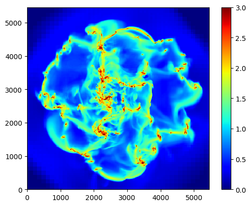

```
elapsed time: 1.330631892 seconds
```

```julia
# PyPlot
tic()
imshow( log10.((Σz.maps[:sd]) * Σz.scale.Msol_pc2).', cmap="jet", origin="lower", vmin=0., vmax=3.)
colorbar()
toc();
```

## Composite Histograms/Profiles + Masking

The data of the full box up to level 13 is used:

```julia
tic()
# get cell positions relative to the center of the box
boxlen = gas.boxlen
ii = select(gas.data, :x) .- boxlen/2.
jj = select(gas.data, :y) .- boxlen/2.

# get radial positions in the x-y plane in kpc
x_val = sqrt.( ii.^2 + jj.^2 ) .* gas.scale.kpc;

# get vertical velocities in km/s
y_val =  abs.(select(gas.data, :vz)) .* gas.scale.km_s; # here we take the absolute values

# define binsizes of both variables x and y
radial_bins = 1.  # kpc
y_bins      = 10.; # km/s
toc();
```

```
elapsed time: 1.93661148 seconds
```

```julia
tic()
hydro_profile = profile(gas, [x_val, y_val],
                             range1=[0., 34.],
                             range2=[1., 1000.],
                             binsize=[radial_bins, y_bins])
toc();
```

```
[Mera] 2018-09-19T17:49:57.514
Using range1: 0.0:1.0:34.0   ->bins=34
Using range2: 1.0:9.99:1000.0   ->bins=100
elapsed time: 22.909150351 seconds
```

```julia
# create a mask for high densities > 100. cm-3
tic()
mask = map.(row->row.rho < 100. / gas.scale.nH, gas.data);
toc();
```

```
elapsed time: 12.770143314 seconds
```

```julia
# only take low densities into account
tic()
hydro_profile_masked = profile(gas, [x_val, y_val],
                                    range1=[0., 34.],
                                    range2=[1., 1000.],
                                    binsize=[radial_bins, y_bins],
                                    mask=mask )
toc();
```

```
[Mera] 2018-09-19T17:51:01.731
Using range1: 0.0:1.0:34.0   ->bins=34
Using range2: 1.0:9.99:1000.0   ->bins=100
elapsed time: 24.806668621 seconds
```

The profile function passes to the object "hydro_profile" a 2d histogram, several profiles (mass-weighted), information from the simulation and helpful variables for plots.

```julia
fieldnames(hydro_profile)
```

```
9-element Array{Symbol,1}:
 :profiles
 :hist2d
 :extent
 :range1
 :range2
 :ratio
 :info
 :time
 :scale
```

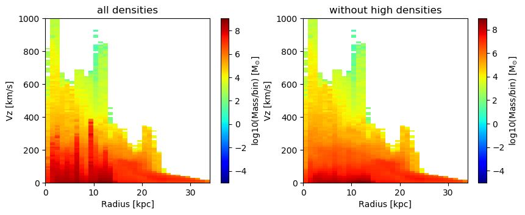

```
elapsed time: 0.147722881 seconds
```

```julia
# PyPlot
tic()
figure(figsize=(10, 3.5))

subplot(1, 2, 1)
im = imshow( log10.(hydro_profile.hist2d .* hydro_profile.scale.Msun).',
                    cmap="jet", aspect=hydro_profile.ratio,
                    extent=hydro_profile.extent, origin="lower",
                    vmin=-5)
xlabel("Radius [kpc]")
ylabel("Vz [km/s]")
cb = PyPlot.colorbar(im, label=L"\mathrm{log10(Mass/bin) \ [M_{\odot}]}")
title("all densities")

subplot(1, 2, 2)
im2 = imshow( log10.(hydro_profile_masked.hist2d .* hydro_profile_masked.scale.Msun).',
                     cmap="jet", aspect=hydro_profile_masked.ratio,
                     extent=hydro_profile_masked.extent, origin="lower",
                     vmin=-5)
xlabel("Radius [kpc]")
ylabel("Vz [km/s]")
cb = PyPlot.colorbar(im2, label=L"\mathrm{log10(Mass/bin) \ [M_{\odot}]}")
title("without high densities")
toc();
```

Several mass-weighted profiles are created:

```julia
fieldnames(hydro_profile.profiles)
```

```
9-element Array{Symbol,1}:
 :xvalues
 :mean
 :median
 :std
 :min
 :max
 :skewness
 :kurtosis
 :sum
```

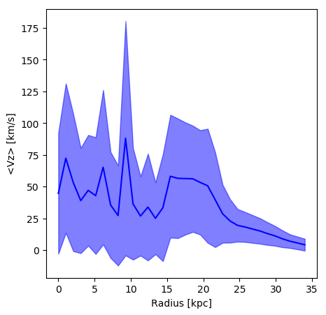

```
elapsed time: 0.024514973 seconds
```

```julia
tic()
figure(figsize=(5,5))
plot(hydro_profile.profiles.xvalues, hydro_profile.profiles.mean , color ="b")
fill_between(   hydro_profile.profiles.xvalues,
                hydro_profile.profiles.mean .-hydro_profile.profiles.std,
                hydro_profile.profiles.mean .+hydro_profile.profiles.std,
                color="b", alpha=0.5)
xlabel("Radius [kpc]")
ylabel("<Vz> [km/s]")
toc();
```

## Export Your (Modified) Data to Binaries for Paraview

[figure not shown]

## Short Overview

At the moment MERA suports data from Hydro, Gravity, Particles, Clump finder. The following tutorials are provided:

[figure not shown]